# Assignment 7

- Nadejda Boev (20056079)
- Due Date - 2022/03/09
- Github user - 16nbb1
- Github link - https://github.com/16nbb1/Biol432_A7

### Added the following dragons to Nexus file

[Ord or 75American](https://dragontales.fandom.com/wiki/Ord) From Dragon Tales created by Jim Coane & John Mariella

[figure not shown]

[Jake Long or 76American](https://adjl.fandom.com/wiki/Jake_Long) From American Dragon: Jake Long (Season 1) created by Jeff Goode

[figure not shown]

[Drogon or 77BritishX](https://hips.hearstapps.com/hmg-prod.s3.amazonaws.com/images/hbz-got-dany-drogon-1505228283.jpg) From Game of Thrones created by David Benioff, D. B. Weiss & George R. R. Martin

[figure not shown]

#### Importing all libraries we’ll need

```r
library(ape)
library(reshape2)
library(ggplot2)
library(ggtree)
library(cowplot)
```

#### Importing Nexus file

```r
DragonNexus<-read.nexus.data("Input/DragonMatrix_NB.nex")
#head(DragonNexus)

# I see my inputs ("75American" "76American" "77BritishX") have been included
names(DragonNexus)
```

```
 [1] "0.1FishXXX" "0.2SnakeXX" "0.3MammalX" "1GermanXXX" "2FrenchXXX" "3FrenchXXX" "4DutchXXXX"
 [8] "5EnglishXX" "6AmericanX" "7FrenchXXX" "8EnglishXX" "9FrenchXXX" "10FrenchXX" "11SpanishX"
[15] "12Japanese" "13Japanese" "14Japanese" "15Japanese" "16Japanese" "17Japanese" "18Japanese"
[22] "19Japanese" "20Japanese" "21Japanese" "22Japanese" "23Japanese" "24Japanese" "25Japanese"
[29] "26Japanese" "27Japanese" "28Japanese" "29Japanese" "30ItalianX" "31ItalianX" "32ItalianX"
[36] "33XXXXXXXX" "34GermanXX" "35EnglishX" "36GermanXX" "37DutchXXX" "38SpanishX" "39ItalianX"
[43] "40ItalianX" "41EnglishX" "42ItalianX" "43SpanishX" "44ItalianX" "45ItalianX" "46EnglishX"
[50] "47ItalianX" "48DutchXXX" "49IndianXX" "50Japanese" "51Japanese" "52Japanese" "53Japanese"
[57] "54IranianX" "55IranianX" "56IranianX" "57IranianX" "58TurkishX" "59IranianX" "60IranianX"
[64] "61TurkishX" "62TurkishX" "63UkraineX" "64UkraineX" "65RussiaXX" "66UkraineX" "67RussiaXX"
[71] "68GreeceXX" "69ItalianX" "70American" "71BritishX" "72BritishX" "73BritishX" "74BritishX"
[78] "75American" "76American" "77BritishX"
```

#### We’re going to build a tree by applying the weights provided

```r
WeightsDat<-read.csv("Input/Weights.csv")
```

#### We need to find the weight for each encoding

```r
Weights<-paste0(WeightsDat$Weight,collapse="")
Weights<-strsplit(Weights,split="")[[1]]
```

#### We need to convert the above letters into values

```r
WeightsNum<-rep(NA,length(Weights))
for(i in 1:length(WeightsNum)){
  if(Weights[i] %in% LETTERS){
    WeightsNum[i]<-which(LETTERS==Weights[i])+9
  } else {
    WeightsNum[i]<-Weights[i]
  }
}
(WeightsNum<-as.numeric(WeightsNum))
```

```
 [1] 35 35 35 35  1  1  1  1 12 12  5  5  5  5  1  1  1  1  1  1  1  1  1  1  1  1  1  1  1  1  7  1
[33]  9  9  9  9  9  9  3  3  3  3  3  3  3  3  3  3  3  3  3  3  3  3  1  1  3  3  3  3  1  3  3  3
[65]  3  3  3  1  4  4  7  1  1 19 19 10 10 10
```

#### Now we need to apply these weights to each dragon, this technically represents evolutionary “importance” / conservation

- This loop through our nexus file and adds RepWeight based on the above list (WeightsNum) in order

```r
WtDragonNexus<-DragonNexus # Make a new weighted data frame object
for (i in 1:length(DragonNexus)){
  RepWeight<-DragonNexus[[i]]==1
  WtDragonNexus[[i]][RepWeight]<-WeightsNum[RepWeight]
  RepWeight<-NA
}
```

#### We can now appropriately create a distance matrix, which includes our weightings

- We are calculating Euclidian distance for each dragon pairing

```r
# We create dataframe/matrix that will hold all the weights for each dragon
WtDragonNexusDF<-data.frame(matrix(unlist(WtDragonNexus),ncol=78,byrow=T))
# Pulls the name of the feature
row.names(WtDragonNexusDF)<-names(WtDragonNexus)
# Calculates distance with weights included
WtDragonDist<-dist(WtDragonNexusDF,method='euclidean')
# This creates a matrix which houses all the comparisons
  # Notice, all diagonal values are 0 since we're comparing the same dragon to itself (no distance/ difference)
WtDragonDistMat<-as.matrix(WtDragonDist)

# Since we we'll use ggtree/ggplot, we need to melt this matrix to be "long", where values hold all the euclidian distances
(WtPDat<-melt(WtDragonDistMat))
```

| Var1 | Var2 | value |
| --- | --- | --- |
| 0.1FishXXX | 0.1FishXXX | 0.000000 |
| 0.2SnakeXX | 0.1FishXXX | 73.423430 |
| 0.3MammalX | 0.1FishXXX | 43.393548 |
| 1GermanXXX | 0.1FishXXX | 46.552499 |
| 2FrenchXXX | 0.1FishXXX | 43.116122 |
| 3FrenchXXX | 0.1FishXXX | 44.510673 |
| 4DutchXXXX | 0.1FishXXX | 43.747298 |
| 5EnglishXX | 0.1FishXXX | 45.069899 |
| 6AmericanX | 0.1FishXXX | 75.342900 |
| 7FrenchXXX | 0.1FishXXX | 45.404662 |

[output cut: 990 more lines]

#### Visualizing the distance matrices

- Sanity check there are values with varying distances and the diagonals are 0

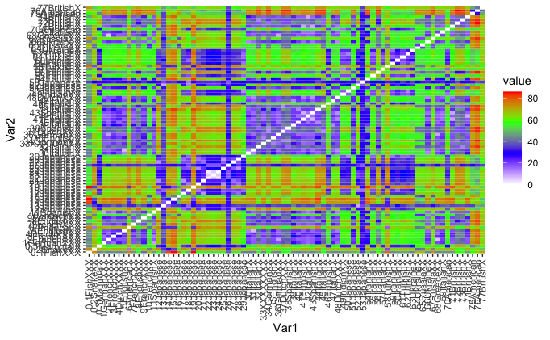

```r
(ggplot(data = WtPDat, aes(x=Var1, y=Var2, fill=value)) +
  geom_tile()+scale_fill_gradientn(colours=c("white","blue","green","red")) +
  theme(axis.text.x = element_text(angle = 90, hjust = 1, vjust = 0.5)))
```

#### We’ll begin with making a basic tree which includes names and nodes

- We’ll print it to find where our 3 dragons lie

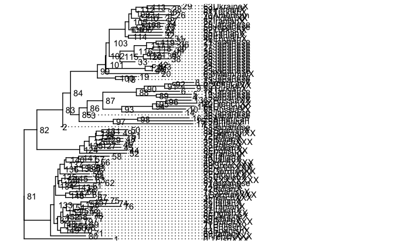

```r
WtDragonTree<-fastme.bal(WtDragonDist)

ggtree(WtDragonTree)+
  geom_tiplab(align=TRUE,) +
    xlim(0, 100)+
  geom_text(aes(label=node), hjust=-.3)
```

```r
# ggsave("images/test.pdf", width = 50, height = 50, units = "cm", limitsize = FALSE)
```

#### I will group and color node 97 and add a background image of a dragon

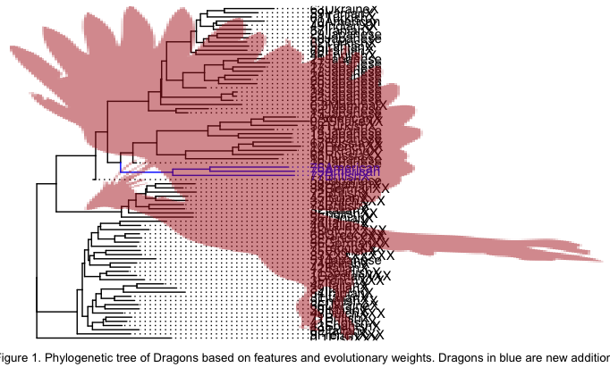

```r
WtDragonTree_2 <- groupClade(WtDragonTree, c(97))

tree = ggtree(WtDragonTree_2, aes(color=group))+
  scale_color_manual(values=c("black", 'blue'))+
  geom_tiplab(align=TRUE,) +
    xlim(0, 100) +
  theme(legend.position="none")+
  geom_phylopic(image="79ad5f09-cf21-4c89-8e7d-0c82a00ce728", size=Inf, alpha=.5, color='firebrick')

ggdraw(add_sub(tree, size =10,
               'Figure 1. Phylogenetic tree of Dragons based on features and evolutionary weights. Dragons in blue are new additions'))

ggsave("images/final.pdf", width = 50, height = 100, units = "cm", limitsize = FALSE)
```

### Appendix A: How I encoded features

1. Ord
- Number of Appendanges = 4 = 1001
- Mass = 1-2x human = 0011
- Body type = Rotund = 00
- Claw type =Short Catlike =1000
- Dorsal ridges =Ridge=010100
- Ear morphology = Absent=000
- Eye morphology =Avg=000
- Eye position =Forward=1
- Horn type =Absent=000
- Nose Position =Forward=1
- Nasal morphology =Upturned=1
- Skin-dorsal =Scaly Skin =100000
- Skin-head =Smooth Skin=110000
- Skin-ventral =Rough Skin=101000
- Snout type = Blunt=1000
- Tail type = Blunt/Point =10
- Teeth =Fangs Only =0011
- Toes-opposing = No=1
- Toe Number = Three=111000
- Tongue length =?
- Tongue morphology =??
- Ventral plates =Yes=1
- Whiskers =Absent=00
- Wing structure=Hybrid=10
- Wing type = Bird=010
2. Jake Long
- Number of Appendanges = 4 = 1001
- Mass = 1-2x human = 0011
- Body type = Elongate = 01
- Claw type =Short Catlike =1000
- Dorsal ridges =Spike=011000
- Ear morphology = Spearlike=010
- Eye morphology =Narrow=010
- Eye position =Forward=1
- Horn type =Absent=000
- Nose Position =Forward=1
- Nasal morphology =other=0
- Skin-dorsal =Smooth Skin=110000
- Skin-head =Hairy=000110
- Skin-ventral =Rough Skin=101000
- Snout type = Blunt=1000
- Tail type = Blunt/Point =10
- Teeth = ????
- Toes-opposing = No=1
- Toe Number = Four=110000
- Tongue length =?
- Tongue morphology =??
- Ventral plates =Yes=1
- Whiskers =Absent=00
- Wing structure=Full=11
- Wing type = Bat=100
3. Drogon
- Number of Appendanges = Two = 1101
- Mass = >4x human = 1111
- Body type = Elongate = 01
- Claw type = Long Talons = 0011
- Dorsal ridges =Spike=011000
- Ear morphology = ???
- Eye morphology =Small=100
- Eye position =Lateral=0
- Horn type =Med/Long =110
- Nose Position =Forward=1
- Nasal morphology =other=0
- Skin-dorsal =Scaly Skin =100000
- Skin-head =Scaly Skin =100000
- Skin-ventral =Scaly Skin =100000
- Snout type = Moderate=1100
- Tail type = Blunt/Point =10
- Teeth =Pointy Only =0000
- Toes-opposing = No=1
- Toe Number = Three=111000
- Tongue length =Short=0
- Tongue morphology =Spear=10
- Ventral plates =No=0
- Whiskers =Absent=00
- Wing structure=Full=11
- Wing type = Bat=100